# Latent growth curves

Source: [`vignettes/articles/growth-curves.qmd`](https://github.com/cdriveraus/ctsem/blob/master/vignettes/articles/growth-curves.qmd)

A latent growth curve model is a special case of a ctsem model. Its process changes at a constant rate, with no random fluctuation, and people differ in where they start and how fast they grow. This article fits a linear growth curve, then two growth processes with several indicators, then lets the measurement error depend on the level of the process.

```r
library(ctsem)
library(ggplot2)
```

## Data

Thirty people, each observed eight times at irregular times. Each person has their own intercept and slope, and people who start higher grow more slowly:

```r
set.seed(3)
nsubjects <- 30
nobs <- 8
intercept <- rnorm(nsubjects, 3, 2)
slope <- rnorm(nsubjects, 0.45, 0.15) - intercept * 0.05
dat <- expand.grid(obs = 1:nobs, id = 1:nsubjects)
dat$time <- dat$obs + runif(nrow(dat), -0.5, 0.5)
dat$eta1 <- intercept[dat$id] + slope[dat$id] * dat$time
dat$y1 <- dat$eta1 + rnorm(nrow(dat), 0, 0.2)
dat <- dat[, c('id', 'time', 'y1', 'eta1')]
head(dat)
```

```
#>   id     time       y1     eta1
#> 1  1 1.216853 1.787250 1.722631
#> 2  1 2.322188 2.132112 2.309882
#> 3  1 3.320742 2.919136 2.840400
#> 4  1 3.699945 3.089174 3.041866
#> 5  1 5.101135 3.700201 3.786300
#> 6  1 5.929836 4.116992 4.226578
```

`eta1` is the true value, which a real data set would not have. It is kept here to compare with the estimates.

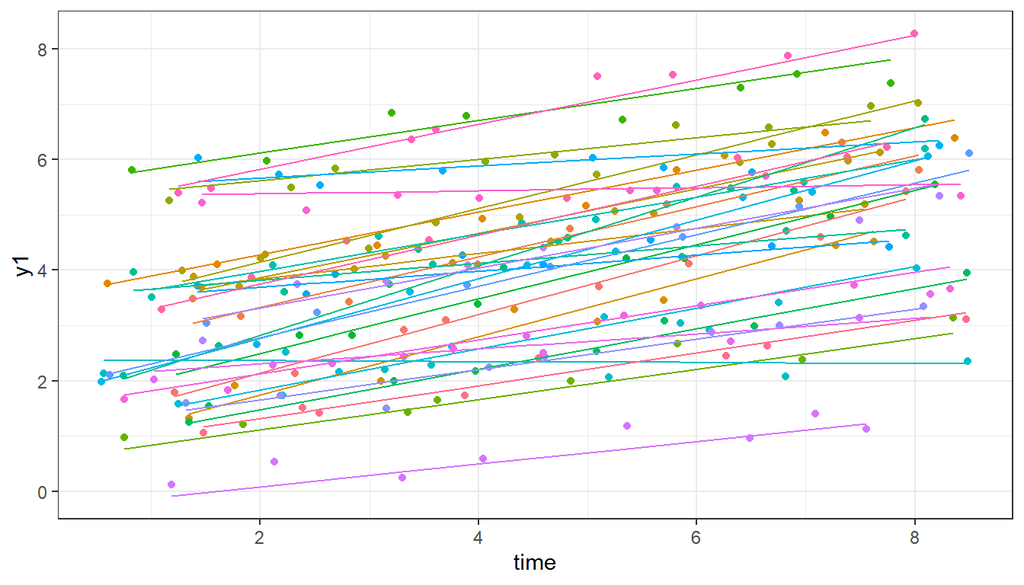

```r
ggplot(dat, aes(time, y1, colour = factor(id))) +
  geom_point() + geom_line(aes(y = eta1)) +
  theme_bw() + guides(colour = 'none')
```

## Linear growth

The default ctsem model is more flexible than linear growth, so a few matrices change:

- `DRIFT = 0`: the rate of change does not depend on the current level;
- `DIFFUSION = 0`: the process does not fluctuate, so change is deterministic;
- `CINT = 'slope'`: the continuous time intercept is the constant rate of change, the slope;
- `MANIFESTMEANS = 0`: the starting level `T0MEANS` takes the place of the intercept.

By default the free intercepts, here the starting level and the slope, vary over people and are correlated. Since the observation times differ within and between people, the model is in continuous time. In discrete time with an interval of one unit, a linear growth curve is the same model.

```r
model <- ctModel(type = 'ct',
  manifestNames = 'y1', latentNames = 'eta1',
  LAMBDA = 1,
  DRIFT = 0,
  DIFFUSION = 0,
  CINT = 'slope',
  MANIFESTMEANS = 0)
```

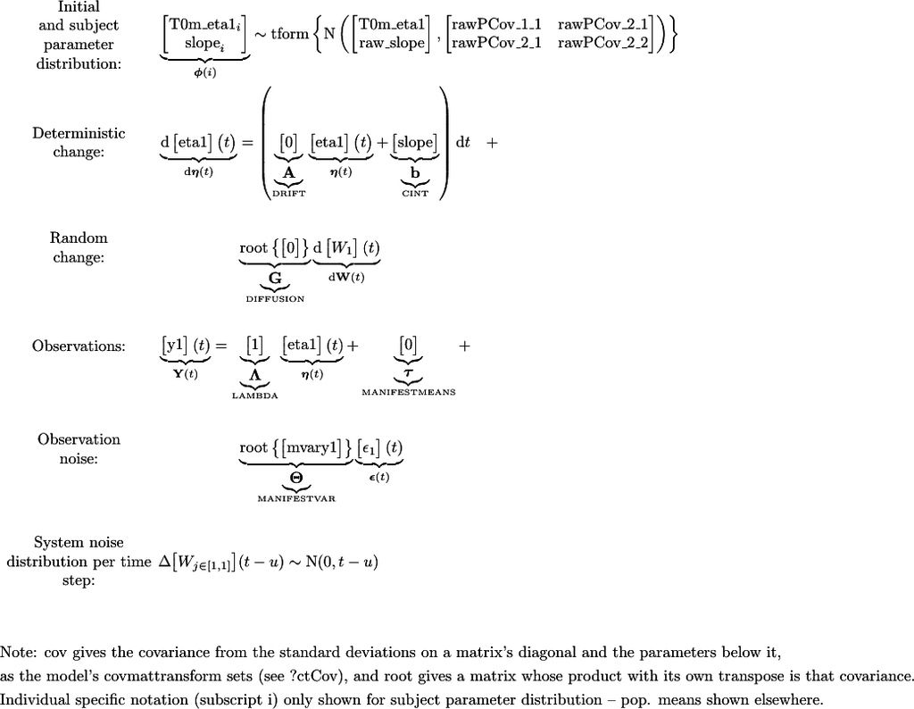

```r
fit <- ctFit(dat, model, cores = 2)
s <- summary(fit)
s$popmeans
```

```
#>           mean    sd  2.5%   50% 97.5%  mode
#> T0m_eta1 2.926 0.274 2.392 2.936 3.424 2.927
#> mvary1   0.207 0.011 0.186 0.207 0.230 0.207
#> slope    0.321 0.028 0.269 0.323 0.376 0.322
```

`T0m_eta1` is the average level at each person’s first observation, and `slope` the average slope. `popsd` gives their standard deviations over people, and `rawpopcorr` their correlation:

```r
s$popsd
```

```
#>           mean    sd  2.5%   50% 97.5%  mode
#> T0m_eta1 1.521 0.199 1.178 1.509 1.940 1.516
#> slope    0.147 0.020 0.112 0.147 0.193 0.147
```

```r
s$rawpopcorr
```

```
#>                   mean    sd   2.5%   50% 97.5%   mode      z
#> slope__T0m_eta1 -0.236 0.171 -0.548 -0.24  0.12 -0.243 -1.381
```

The true values for these thirty people, which the estimates should be close to:

```r
first <- dat[!duplicated(dat$id), ]
c(start_mean = mean(first$eta1), slope_mean = mean(slope),
  start_sd = sd(first$eta1), slope_sd = sd(slope),
  correlation = cor(first$eta1, slope))
```

```
#>  start_mean  slope_mean    start_sd    slope_sd correlation
#>   2.8948018   0.3275297   1.5681417   0.1591997  -0.2722724
```

`ctPredict()` shows the predictions for a few people. The predicted values (`yprior`) use each person’s earlier observations only. Before the first observation the prediction is the population average, and with each observation the person’s own starting level and slope are learned:

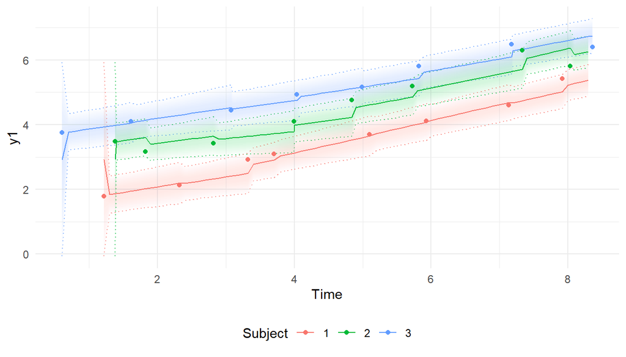

```r
ctPredict(fit, subjects = 1:3, timestep = 0.1, plot = TRUE,
  kalmanvec = c('y', 'yprior'))
```

The smoothed values (`ysmooth`) use all of each person’s observations:

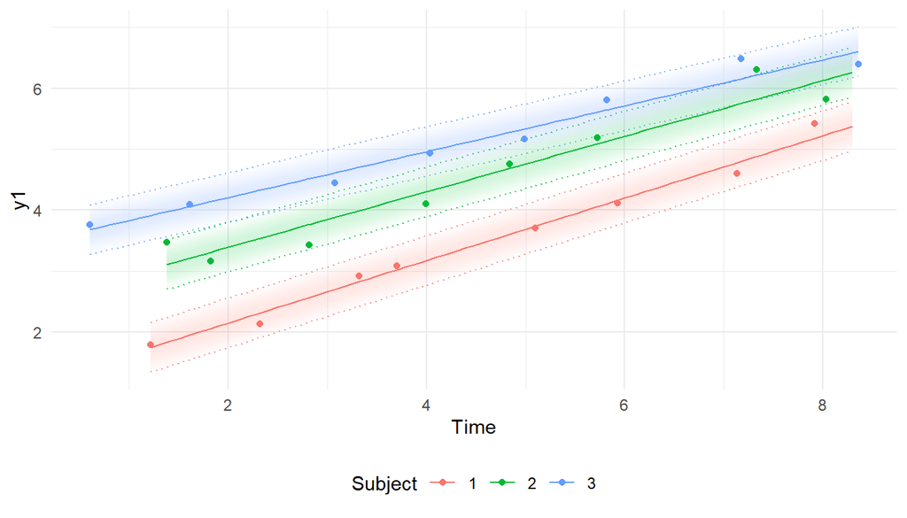

```r
ctPredict(fit, subjects = 1:3, timestep = 0.1, plot = TRUE,
  kalmanvec = c('y', 'ysmooth'))
```

## Two processes and several indicators

A second process, `eta2`, has its own starting levels, related to those of `eta1`, and declines by 0.2 per unit of time on average. It is measured by two variables: `y2`, and `y3` with a loading of 0.8 and an intercept of 3.

```r
intercept2 <- 1 + 0.5 * intercept + rnorm(nsubjects, 0, 1)
slope2 <- rnorm(nsubjects, -0.2, 0.1)
dat$eta2 <- intercept2[dat$id] + slope2[dat$id] * dat$time
dat$y2 <- dat$eta2 + rnorm(nrow(dat), 0, 0.5)
dat$y3 <- 3 + 0.8 * dat$eta2 + rnorm(nrow(dat), 0, 0.3)
```

In the model each process has a starting level and a slope. `y2` has a loading of 1 and an intercept of 0, which set the scale of `eta2`, and `y3` gets a free loading and a free intercept. The intercept is the same for everyone, which `indvarying = FALSE` in its string says.

```r
model2 <- ctModel(type = 'ct',
  manifestNames = c('y1', 'y2', 'y3'),
  latentNames = c('eta1', 'eta2'),
  DRIFT = 0,
  DIFFUSION = 0,
  CINT = c('slope1', 'slope2'),
  T0MEANS = c('int1', 'int2'),
  MANIFESTMEANS = c(0, 0, 'manintercept3, indvarying = FALSE'),
  LAMBDA = c(
    1, 0,
    0, 1,
    0, 'lambda3'))
```

`ctModelLatex()` shows the structure:

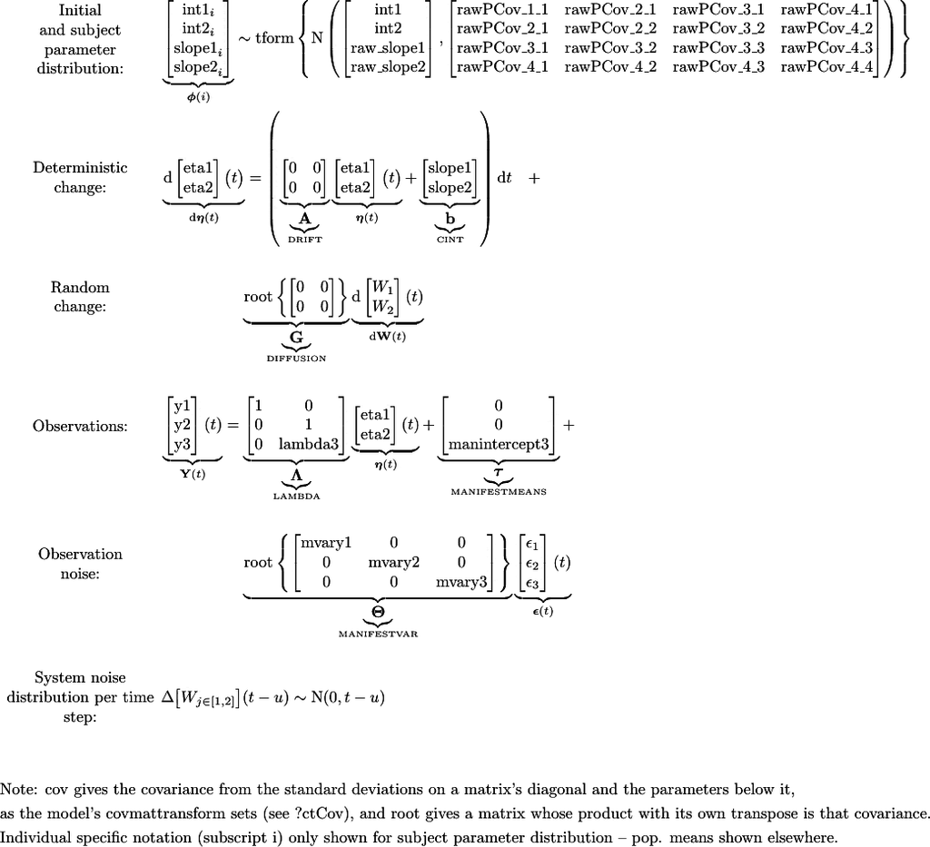

```r
fit2 <- ctFit(dat, model2, cores = 2)
summary(fit2)$popmeans
```

```
#>                 mean    sd   2.5%    50%  97.5%   mode
#> int1           2.927 0.277  2.391  2.921  3.464  2.928
#> int2           1.977 0.261  1.493  1.967  2.483  1.969
#> lambda3        0.801 0.020  0.760  0.801  0.841  0.802
#> mvary1         0.207 0.011  0.187  0.206  0.230  0.207
#> mvary2         0.504 0.024  0.457  0.504  0.552  0.504
#> mvary3         0.305 0.016  0.275  0.305  0.337  0.304
#> manintercept3  2.943 0.040  2.864  2.942  3.022  2.941
#> slope1         0.321 0.027  0.268  0.321  0.374  0.322
#> slope2        -0.205 0.021 -0.248 -0.205 -0.165 -0.206
```

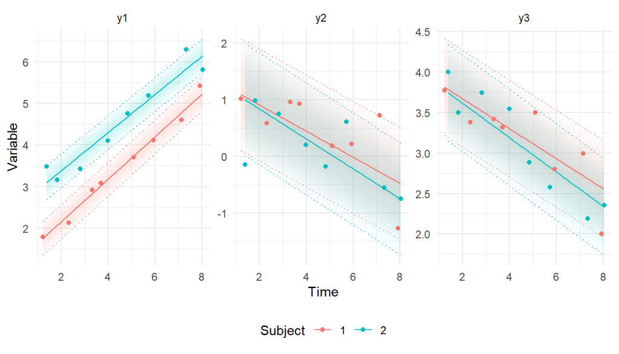

```r
ctPredict(fit2, subjects = 1:2, timestep = 0.1, plot = TRUE,
  kalmanvec = c('y', 'ysmooth'))
```

## Measurement error that depends on the level

A measurement instrument may work better for some values of the process than for others. Here the measurement error of `y1` grows with the level of `eta1`:

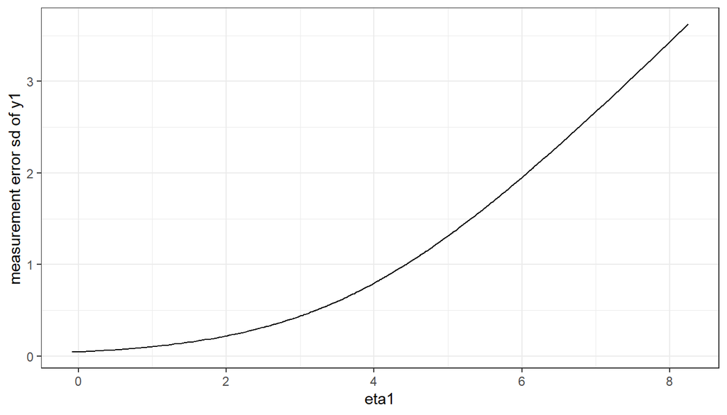

```r
dat$y1 <- dat$eta1 + rnorm(nrow(dat), 0, log1p_exp(0.8 * dat$eta1 - 3))
ggplot(dat, aes(eta1, log1p_exp(0.8 * eta1 - 3))) + geom_line() +
  labs(y = 'measurement error sd of y1') + theme_bw()
```

The measurement error cell of the model becomes an expression in the latent process. `log1p_exp()` keeps the standard deviation positive. Free parameters inside an expression are declared in `PARS`:

```r
model3 <- ctModel(type = 'ct',
  manifestNames = 'y1', latentNames = 'eta1',
  LAMBDA = 1,
  DRIFT = 0,
  DIFFUSION = 0,
  CINT = 'slope',
  MANIFESTMEANS = 0,
  MANIFESTVAR = 'log1p_exp(errorsd_intercept + errorsd_byeta1 * eta1)',
  PARS = c('errorsd_intercept', 'errorsd_byeta1'))
fit3 <- ctFit(dat, model3, cores = 2)
summary(fit3)$popmeans
```

```
#>                     mean    sd   2.5%    50%  97.5%   mode
#> T0m_eta1           2.874 0.270  2.332  2.875  3.397  2.867
#> slope              0.347 0.043  0.262  0.349  0.428  0.347
#> errorsd_intercept -2.909 0.188 -3.247 -2.907 -2.563 -2.904
#> errorsd_byeta1     0.780 0.054  0.678  0.781  0.886  0.779
```

The generating values were -3 for the intercept and 0.8 for the effect of `eta1`. The band around each smoothed trajectory includes the measurement error, which is much smaller for person 4, whose level is lower:

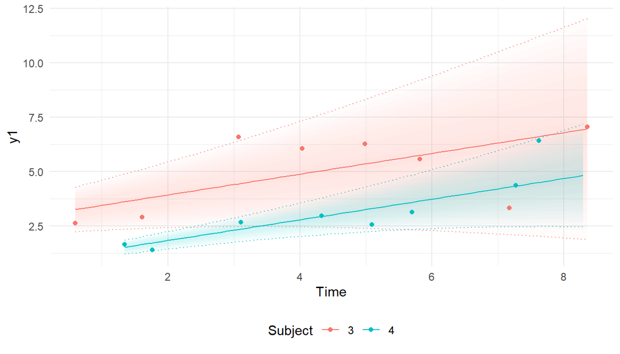

```r
ctPredict(fit3, subjects = c(3, 4), timestep = 0.1, plot = TRUE,
  kalmanvec = c('y', 'ysmooth'))
```

`vignette('measurement-models')` has more on measurement that depends on the state, including loadings.